# 15 Screening Many Models

Min-Yao

2024-03-18

# Screening Many Models

We introduced workflow sets in Chapter @ref(workflows) and demonstrated how to use them with resampled data sets in Chapter @ref(compare). In this chapter, we discuss these sets of multiple modeling workflows in more detail and describe a use case where they can be helpful.

For projects with new data sets that have not yet been well understood, a data practitioner may need to screen many combinations of models and preprocessors. It is common to have little or no *a priori* knowledge about which method will work best with a novel data set.

A good strategy is to spend some initial effort trying a variety of modeling approaches, determine what works best, then invest additional time tweaking/optimizing a small set of models.

Workflow sets provide a user interface to create and manage this process. We’ll also demonstrate how to evaluate these models efficiently using the racing methods discussed in Section @ref(racing-example).

## Modeling Concrete Mixture Strength

To demonstrate how to screen multiple model workflows, we will use the concrete mixture data from *Applied Predictive Modeling* [@apm] as an example. Chapter 10 of that book demonstrated models to predict the compressive strength of concrete mixtures using the ingredients as predictors. A wide variety of models were evaluated with different predictor sets and preprocessing needs. How can workflow sets make such a process of large scale testing for models easier?

First, let’s define the data splitting and resampling schemes.

```r
library(tidymodels)
tidymodels_prefer()
data(concrete, package = "modeldata")
glimpse(concrete)
```

```
## Rows: 1,030
## Columns: 9
## $ cement               <dbl> 540.0, 540.0, 332.5, 332.5, 198.6, 266.0, 380.0, …
## $ blast_furnace_slag   <dbl> 0.0, 0.0, 142.5, 142.5, 132.4, 114.0, 95.0, 95.0,…
## $ fly_ash              <dbl> 0, 0, 0, 0, 0, 0, 0, 0, 0, 0, 0, 0, 0, 0, 0, 0, 0…
## $ water                <dbl> 162, 162, 228, 228, 192, 228, 228, 228, 228, 228,…
## $ superplasticizer     <dbl> 2.5, 2.5, 0.0, 0.0, 0.0, 0.0, 0.0, 0.0, 0.0, 0.0,…
## $ coarse_aggregate     <dbl> 1040.0, 1055.0, 932.0, 932.0, 978.4, 932.0, 932.0…
## $ fine_aggregate       <dbl> 676.0, 676.0, 594.0, 594.0, 825.5, 670.0, 594.0, …
## $ age                  <int> 28, 28, 270, 365, 360, 90, 365, 28, 28, 28, 90, 2…
## $ compressive_strength <dbl> 79.99, 61.89, 40.27, 41.05, 44.30, 47.03, 43.70, …
```

The `compressive_strength` column is the outcome. The `age` predictor tells us the age of the concrete sample at testing in days (concrete strengthens over time) and the rest of the predictors like `cement` and `water` are concrete components in units of kilograms per cubic meter.

For some cases in this data set, the same concrete formula was tested multiple times. We’d rather not include these replicate mixtures as individual data points since they might be distributed across both the training and test set. Doing so might artificially inflate our performance estimates.

To address this, we will use the mean compressive strength per concrete mixture for modeling:

```r
concrete <-
   concrete %>%
   group_by(across(-compressive_strength)) %>%
   summarize(compressive_strength = mean(compressive_strength),
             .groups = "drop")
nrow(concrete)
```

```
## [1] 992
```

Let’s split the data using the default 3:1 ratio of training-to-test and resample the training set using five repeats of 10-fold cross-validation:

```r
set.seed(1501)
concrete_split <- initial_split(concrete, strata = compressive_strength)
concrete_train <- training(concrete_split)
concrete_test  <- testing(concrete_split)

set.seed(1502)
concrete_folds <-
   vfold_cv(concrete_train, strata = compressive_strength, repeats = 5)
```

Some models (notably neural networks, KNN, and support vector machines) require predictors that have been centered and scaled, so some model workflows will require recipes with these preprocessing steps. For other models, a traditional response surface design model expansion (i.e., quadratic and two-way interactions) is a good idea. For these purposes, we create two recipes:

```r
normalized_rec <-
   recipe(compressive_strength ~ ., data = concrete_train) %>%
   step_normalize(all_predictors())

poly_recipe <-
   normalized_rec %>%
   step_poly(all_predictors()) %>%
   step_interact(~ all_predictors():all_predictors())
```

For the models, we use the the `pkg(parsnip)` addin to create a set of model specifications:

```r
library(rules)
library(baguette)

linear_reg_spec <-
   linear_reg(penalty = tune(), mixture = tune()) %>%
   set_engine("glmnet")

nnet_spec <-
   mlp(hidden_units = tune(), penalty = tune(), epochs = tune()) %>%
   set_engine("nnet", MaxNWts = 2600) %>%
   set_mode("regression")

mars_spec <-
   mars(prod_degree = tune()) %>%  #<- use GCV to choose terms
   set_engine("earth") %>%
   set_mode("regression")

svm_r_spec <-
   svm_rbf(cost = tune(), rbf_sigma = tune()) %>%
   set_engine("kernlab") %>%
   set_mode("regression")

svm_p_spec <-
   svm_poly(cost = tune(), degree = tune()) %>%
   set_engine("kernlab") %>%
   set_mode("regression")

knn_spec <-
   nearest_neighbor(neighbors = tune(), dist_power = tune(), weight_func = tune()) %>%
   set_engine("kknn") %>%
   set_mode("regression")

cart_spec <-
   decision_tree(cost_complexity = tune(), min_n = tune()) %>%
   set_engine("rpart") %>%
   set_mode("regression")

bag_cart_spec <-
   bag_tree() %>%
   set_engine("rpart", times = 50L) %>%
   set_mode("regression")

rf_spec <-
   rand_forest(mtry = tune(), min_n = tune(), trees = 1000) %>%
   set_engine("ranger") %>%
   set_mode("regression")

xgb_spec <-
   boost_tree(tree_depth = tune(), learn_rate = tune(), loss_reduction = tune(),
              min_n = tune(), sample_size = tune(), trees = tune()) %>%
   set_engine("xgboost") %>%
   set_mode("regression")

cubist_spec <-
   cubist_rules(committees = tune(), neighbors = tune()) %>%
   set_engine("Cubist")
```

The analysis in @apm specifies that the neural network should have up to 27 hidden units in the layer. The `extract_parameter_set_dials()` function extracts the parameter set, which we modify to have the correct parameter range:

```r
nnet_param <-
   nnet_spec %>%
   extract_parameter_set_dials() %>%
   update(hidden_units = hidden_units(c(1, 27)))
```

How can we match these models to their recipes, tune them, then evaluate their performance efficiently? A workflow set offers a solution.

## Creating the Workflow Set

Workflow sets take named lists of preprocessors and model specifications and combine them into an object containing multiple workflows. There are three possible kinds of preprocessors:

- A standard R formula
- A recipe object (prior to estimation/prepping)
- A `pkg(dplyr)`-style selector to choose the outcome and predictors

As a first workflow set example, let’s combine the recipe that only standardizes the predictors to the nonlinear models that require the predictors to be in the same units:

```r
normalized <-
   workflow_set(
      preproc = list(normalized = normalized_rec),
      models = list(SVM_radial = svm_r_spec, SVM_poly = svm_p_spec,
                    KNN = knn_spec, neural_network = nnet_spec)
   )
normalized
```

```
## # A workflow set/tibble: 4 × 4
##   wflow_id                  info             option    result
##   <chr>                     <list>           <list>    <list>
## 1 normalized_SVM_radial     <tibble [1 × 4]> <opts[0]> <list [0]>
## 2 normalized_SVM_poly       <tibble [1 × 4]> <opts[0]> <list [0]>
## 3 normalized_KNN            <tibble [1 × 4]> <opts[0]> <list [0]>
## 4 normalized_neural_network <tibble [1 × 4]> <opts[0]> <list [0]>
```

Since there is only a single preprocessor, this function creates a set of workflows with this value. If the preprocessor contained more than one entry, the function would create all combinations of preprocessors and models.

The `wflow_id` column is automatically created but can be modified using a call to `mutate()`. The `info` column contains a tibble with some identifiers and the workflow object. The workflow can be extracted:

```r
normalized %>% extract_workflow(id = "normalized_KNN")
```

```
## ══ Workflow ════════════════════════════════════════════════════════════════════
## Preprocessor: Recipe
## Model: nearest_neighbor()
##
## ── Preprocessor ────────────────────────────────────────────────────────────────
## 1 Recipe Step
##
## • step_normalize()
##
## ── Model ───────────────────────────────────────────────────────────────────────
## K-Nearest Neighbor Model Specification (regression)
##
## Main Arguments:
##   neighbors = tune()
##   weight_func = tune()
##   dist_power = tune()
##
## Computational engine: kknn
```

The `option` column is a placeholder for any arguments to use when we evaluate the workflow. For example, to add the neural network parameter object:

```r
normalized <-
   normalized %>%
   option_add(param_info = nnet_param, id = "normalized_neural_network")
normalized
```

```
## # A workflow set/tibble: 4 × 4
##   wflow_id                  info             option    result
##   <chr>                     <list>           <list>    <list>
## 1 normalized_SVM_radial     <tibble [1 × 4]> <opts[0]> <list [0]>
## 2 normalized_SVM_poly       <tibble [1 × 4]> <opts[0]> <list [0]>
## 3 normalized_KNN            <tibble [1 × 4]> <opts[0]> <list [0]>
## 4 normalized_neural_network <tibble [1 × 4]> <opts[1]> <list [0]>
```

When a function from the `pkg(tune)` or `pkg(finetune)` package is used to tune (or resample) the workflow, this argument will be used.

The `result` column is a placeholder for the output of the tuning or resampling functions.

For the other nonlinear models, let’s create another workflow set that uses `pkg(dplyr)` selectors for the outcome and predictors:

```r
model_vars <-
   workflow_variables(outcomes = compressive_strength,
                      predictors = everything())

no_pre_proc <-
   workflow_set(
      preproc = list(simple = model_vars),
      models = list(MARS = mars_spec, CART = cart_spec, CART_bagged = bag_cart_spec,
                    RF = rf_spec, boosting = xgb_spec, Cubist = cubist_spec)
   )
no_pre_proc
```

```
## # A workflow set/tibble: 6 × 4
##   wflow_id           info             option    result
##   <chr>              <list>           <list>    <list>
## 1 simple_MARS        <tibble [1 × 4]> <opts[0]> <list [0]>
## 2 simple_CART        <tibble [1 × 4]> <opts[0]> <list [0]>
## 3 simple_CART_bagged <tibble [1 × 4]> <opts[0]> <list [0]>
## 4 simple_RF          <tibble [1 × 4]> <opts[0]> <list [0]>
## 5 simple_boosting    <tibble [1 × 4]> <opts[0]> <list [0]>
## 6 simple_Cubist      <tibble [1 × 4]> <opts[0]> <list [0]>
```

Finally, we assemble the set that uses nonlinear terms and interactions with the appropriate models:

```r
with_features <-
   workflow_set(
      preproc = list(full_quad = poly_recipe),
      models = list(linear_reg = linear_reg_spec, KNN = knn_spec)
   )
```

These objects are tibbles with the extra class of `workflow_set`. Row binding does not affect the state of the sets and the result is itself a workflow set:

```r
all_workflows <-
   bind_rows(no_pre_proc, normalized, with_features) %>%
   # Make the workflow ID's a little more simple:
   mutate(wflow_id = gsub("(simple_)|(normalized_)", "", wflow_id))
all_workflows
```

```
## # A workflow set/tibble: 12 × 4
##    wflow_id             info             option    result
##    <chr>                <list>           <list>    <list>
##  1 MARS                 <tibble [1 × 4]> <opts[0]> <list [0]>
##  2 CART                 <tibble [1 × 4]> <opts[0]> <list [0]>
##  3 CART_bagged          <tibble [1 × 4]> <opts[0]> <list [0]>
##  4 RF                   <tibble [1 × 4]> <opts[0]> <list [0]>
##  5 boosting             <tibble [1 × 4]> <opts[0]> <list [0]>
##  6 Cubist               <tibble [1 × 4]> <opts[0]> <list [0]>
##  7 SVM_radial           <tibble [1 × 4]> <opts[0]> <list [0]>
##  8 SVM_poly             <tibble [1 × 4]> <opts[0]> <list [0]>
##  9 KNN                  <tibble [1 × 4]> <opts[0]> <list [0]>
## 10 neural_network       <tibble [1 × 4]> <opts[1]> <list [0]>
## 11 full_quad_linear_reg <tibble [1 × 4]> <opts[0]> <list [0]>
## 12 full_quad_KNN        <tibble [1 × 4]> <opts[0]> <list [0]>
```

## Tuning and Evaluating the Models

Almost all of the members of `all_workflows` contain tuning parameters. To evaluate their performance, we can use the standard tuning or resampling functions (e.g., `tune_grid()` and so on). The `workflow_map()` function will apply the same function to all of the workflows in the set; the default is `tune_grid()`.

```r
grid_ctrl <-
   control_grid(
      save_pred = TRUE,
      parallel_over = "everything",
      save_workflow = TRUE
   )

grid_results <-
   all_workflows %>%
   workflow_map(
      seed = 1503,
      resamples = concrete_folds,
      grid = 10,
      control = grid_ctrl
   )
grid_results
```

The results show that the `option` and `result` columns have been updated:

```r
grid_results
```

```
## # A workflow set/tibble: 12 × 4
##    wflow_id             info             option    result
##    <chr>                <list>           <list>    <list>
##  1 MARS                 <tibble [1 × 4]> <opts[3]> <tune[+]>
##  2 CART                 <tibble [1 × 4]> <opts[3]> <tune[+]>
##  3 CART_bagged          <tibble [1 × 4]> <opts[3]> <rsmp[+]>
##  4 RF                   <tibble [1 × 4]> <opts[3]> <tune[+]>
##  5 boosting             <tibble [1 × 4]> <opts[3]> <tune[+]>
##  6 Cubist               <tibble [1 × 4]> <opts[3]> <tune[+]>
##  7 SVM_radial           <tibble [1 × 4]> <opts[3]> <tune[+]>
##  8 SVM_poly             <tibble [1 × 4]> <opts[3]> <tune[+]>
##  9 KNN                  <tibble [1 × 4]> <opts[3]> <tune[+]>
## 10 neural_network       <tibble [1 × 4]> <opts[4]> <tune[+]>
## 11 full_quad_linear_reg <tibble [1 × 4]> <opts[3]> <tune[+]>
## 12 full_quad_KNN        <tibble [1 × 4]> <opts[3]> <tune[+]>
```

The `option` column now contains all of the options that we used in the `workflow_map()` call. This makes our results reproducible. In the `result` columns, the “`tune[+]`” and “`rsmp[+]`” notations mean that the object had no issues. A value such as “`tune[x]`” occurs if all of the models failed for some reason.

There are a few convenience functions for examining results such as `grid_results`. The `rank_results()` function will order the models by some performance metric. By default, it uses the first metric in the metric set (RMSE in this instance). Let’s `filter()` to look only at RMSE:

```r
grid_results %>%
   rank_results() %>%
   filter(.metric == "rmse") %>%
   select(model, .config, rmse = mean, rank)
```

```
## # A tibble: 103 × 4
##    model        .config                rmse  rank
##    <chr>        <chr>                 <dbl> <int>
##  1 boost_tree   Preprocessor1_Model07  4.26     1
##  2 boost_tree   Preprocessor1_Model09  4.52     2
##  3 cubist_rules Preprocessor1_Model07  4.72     3
##  4 boost_tree   Preprocessor1_Model02  4.75     4
##  5 cubist_rules Preprocessor1_Model10  4.77     5
##  6 cubist_rules Preprocessor1_Model09  4.78     6
##  7 cubist_rules Preprocessor1_Model03  4.85     7
##  8 cubist_rules Preprocessor1_Model05  4.86     8
##  9 boost_tree   Preprocessor1_Model05  4.96     9
## 10 cubist_rules Preprocessor1_Model04  4.96    10
## # ℹ 93 more rows
```

Also by default, the function ranks all of the candidate sets; that’s why the same model can show up multiple times in the output. An option, called `select_best`, can be used to rank the models using their best tuning parameter combination.

The `autoplot()` method plots the rankings; it also has a `select_best` argument. The plot in Figure @ref(fig:workflow-set-ranks) visualizes the best results for each model and is generated with:

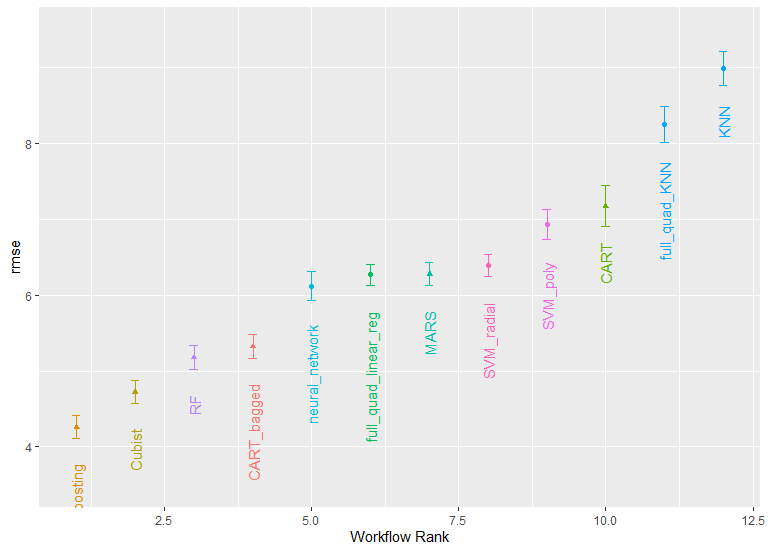

Estimated RMSE (and approximate confidence intervals) for the best model configuration in each workflow.

```r
autoplot(
   grid_results,
   rank_metric = "rmse",  # <- how to order models
   metric = "rmse",       # <- which metric to visualize
   select_best = TRUE     # <- one point per workflow
) +
   geom_text(aes(y = mean - 1/2, label = wflow_id), angle = 90, hjust = 1) +
   lims(y = c(3.5, 9.5)) +
   theme(legend.position = "none")
```

In case you want to see the tuning parameter results for a specific model, like Figure @ref(fig:workflow-sets-autoplot), the `id` argument can take a single value from the `wflow_id` column for which model to plot:

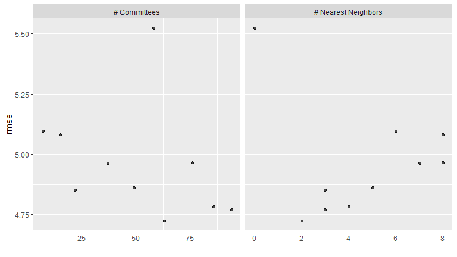

The `autoplot()` results for the Cubist model contained in the workflow set.

```r
autoplot(grid_results, id = "Cubist", metric = "rmse")
```

There are also methods for `collect_predictions()` and `collect_metrics()`.

## Efficiently Screening Models

One effective method for screening a large set of models efficiently is to use the racing approach described in Section @ref(racing). With a workflow set, we can use the `workflow_map()` function for this racing approach. Recall that after we pipe in our workflow set, the argument we use is the function to apply to the workflows; in this case, we can use a value of `"tune_race_anova"`. We also pass an appropriate control object; otherwise the options would be the same as the code in the previous section.

```r
library(finetune)

race_ctrl <-
   control_race(
      save_pred = TRUE,
      parallel_over = "everything",
      save_workflow = TRUE
   )

race_results <-
   all_workflows %>%
   workflow_map(
      "tune_race_anova",
      seed = 1503,
      resamples = concrete_folds,
      grid = 10,
      control = race_ctrl
   )
```

The new object looks very similar, although the elements of the `result` column show a value of `"race[+]"`, indicating a different type of object:

```r
race_results
```

```
## # A workflow set/tibble: 12 × 4
##    wflow_id             info             option    result
##    <chr>                <list>           <list>    <list>
##  1 MARS                 <tibble [1 × 4]> <opts[3]> <race[+]>
##  2 CART                 <tibble [1 × 4]> <opts[3]> <race[+]>
##  3 CART_bagged          <tibble [1 × 4]> <opts[3]> <rsmp[+]>
##  4 RF                   <tibble [1 × 4]> <opts[3]> <race[+]>
##  5 boosting             <tibble [1 × 4]> <opts[3]> <race[+]>
##  6 Cubist               <tibble [1 × 4]> <opts[3]> <race[+]>
##  7 SVM_radial           <tibble [1 × 4]> <opts[3]> <race[+]>
##  8 SVM_poly             <tibble [1 × 4]> <opts[3]> <race[+]>
##  9 KNN                  <tibble [1 × 4]> <opts[3]> <race[+]>
## 10 neural_network       <tibble [1 × 4]> <opts[4]> <race[+]>
## 11 full_quad_linear_reg <tibble [1 × 4]> <opts[3]> <race[+]>
## 12 full_quad_KNN        <tibble [1 × 4]> <opts[3]> <race[+]>
```

The same helpful functions are available for this object to interrogate the results and, in fact, the basic `autoplot()` method shown in Figure @ref(fig:workflow-set-racing-ranks)[^1] produces trends similar to Figure @ref(fig:workflow-set-ranks). This is produced by:

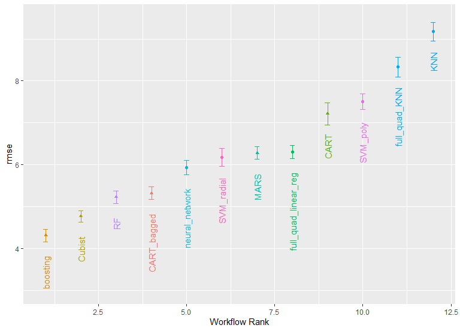

Estimated RMSE (and approximate confidence intervals) for the best model configuration in each workflow in the racing results.

```r
autoplot(
   race_results,
   rank_metric = "rmse",
   metric = "rmse",
   select_best = TRUE
) +
   geom_text(aes(y = mean - 1/2, label = wflow_id), angle = 90, hjust = 1) +
   lims(y = c(3.0, 9.5)) +
   theme(legend.position = "none")
```

Did we get similar results? For both objects, we rank the results, merge them, and plot them against one another in Figure @ref(fig:racing-concordance).

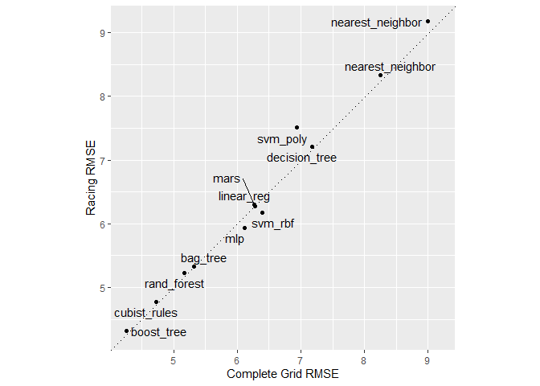

Estimated RMSE for the full grid and racing results.

```r
matched_results <-
   rank_results(race_results, select_best = TRUE) %>%
   select(wflow_id, .metric, race = mean, config_race = .config) %>%
   inner_join(
      rank_results(grid_results, select_best = TRUE) %>%
         select(wflow_id, .metric, complete = mean,
                config_complete = .config, model),
      by = c("wflow_id", ".metric"),
   ) %>%
   filter(.metric == "rmse")

library(ggrepel)

matched_results %>%
   ggplot(aes(x = complete, y = race)) +
   geom_abline(lty = 3) +
   geom_point() +
   geom_text_repel(aes(label = model)) +
   coord_obs_pred() +
   labs(x = "Complete Grid RMSE", y = "Racing RMSE")
```

## Finalizing a Model

Similar to what we have shown in previous chapters, the process of choosing the final model and fitting it on the training set is straightforward. The first step is to pick a workflow to finalize. Since the boosted tree model worked well, we’ll extract that from the set, update the parameters with the numerically best settings, and fit to the training set:

```r
best_results <-
   race_results %>%
   extract_workflow_set_result("boosting") %>%
   select_best(metric = "rmse")
best_results
```

```
## # A tibble: 1 × 7
##   trees min_n tree_depth learn_rate loss_reduction sample_size .config
##   <int> <int>      <int>      <dbl>          <dbl>       <dbl> <chr>
## 1  1905    17         13      0.152   0.0000000117       0.801 Preprocessor1_Mo…
```

```r
boosting_test_results <-
   race_results %>%
   extract_workflow("boosting") %>%
   finalize_workflow(best_results) %>%
   last_fit(split = concrete_split)
```

We can see the test set metrics results, and visualize the predictions in Figure @ref(fig:concrete-test-results).

```r
collect_metrics(boosting_test_results)
```

```
## # A tibble: 2 × 4
##   .metric .estimator .estimate .config
##   <chr>   <chr>          <dbl> <chr>
## 1 rmse    standard       3.44  Preprocessor1_Model1
## 2 rsq     standard       0.953 Preprocessor1_Model1
```

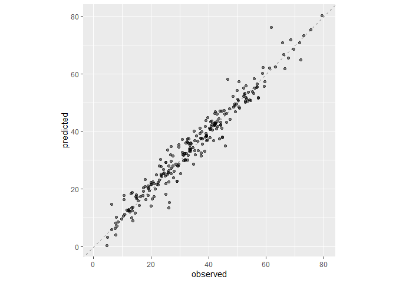

Observed versus predicted values for the test set.

```r
boosting_test_results %>%
   collect_predictions() %>%
   ggplot(aes(x = compressive_strength, y = .pred)) +
   geom_abline(color = "gray50", lty = 2) +
   geom_point(alpha = 0.5) +
   coord_obs_pred() +
   labs(x = "observed", y = "predicted")
```

We see here how well the observed and predicted compressive strength for these concrete mixtures align.

## Chapter Summary

Often a data practitioner needs to consider a large number of possible modeling approaches for a task at hand, especially for new data sets and/or when there is little knowledge about what modeling strategy will work best. This chapter illustrated how to use workflow sets to investigate multiple models or feature engineering strategies in such a situation. Racing methods can more efficiently rank models than fitting every candidate model being considered.

[^1]: As of February 2022, we see slightly different performance metrics for the neural network when trained using macOS on ARM architecture (Apple M1 chip) compared to Intel architecture.